# Resumen de R

Tratamiento de Datos. Grado en Ciencia de Datos - UV

Carlos Santiago Martinez Torres

2025-04-22

# Antes de empezar

Siempre usar pacman para cargar las librerias

```r
# Asegurarse de que el paquete "pacman" está instalado
if (!require("pacman")) install.packages("pacman")
```

Listado de librerias que se han implementado a lo largo del curso

```r
pacman::p_load(tidyverse, readxl, lubridate, visdat, stringdist, fuzzyjoin, reclin)
```

```r
# Con tidyverse: ggplot2, dplyr, tidyr, readr, purrr, tibble, stringr, forcats
# readxl, libreria que requiere una carga aparte explícita
# lubridate, se utiliza con frecuencia con paquetes de tidyverse, pero requiere una carga aparte
# visdat, exploracion visual de los datos
# stringdist: Approximate String Matching, Fuzzy Text Search, and String Distance Functions
# Fuzzyjoin, para unir df's por medio de string distances
# reclin, para pares de datos. Record Linkage
```

# CAPITULO 1

```r
# library(dplyr)
# library(stringr)
```

Problemas comunes que se pueden tener con los datos cuando no están limpios. Por que limpiarlos? Porque el error aparece al inicio de los datos. Es decir:

Error humano, acceso a datos, exploración de los datos, extracción de datos y reporte.

Si no se soluciona, todo el código ira con el error humano.

Limitaciones de tipo de dato:

- Texto, que es el ‘character’
- Entero, ‘integer’
- Decimal, ‘numeric’
- Binario, ‘logical’
- Categórico, ‘factor’
- Fecha, ‘date’

## Chequeando el tipo de dato

- sales <- read.csv(‘sales.csv’)
- head(sales)

Para saber el tipo de dato que estamos usando:

- Columna <- sales$revenue
- Is.numeric(columna)

Si no, con la librería assertive:

- Library(assertive)
- Assert_is_numeric(columna)

Cuando usamos expresiones como:

- Is.numeric(), is.character(), is.logical(), etc…

Estamos evaluando expresiones que nos devuelven un return TRUE/FALSE.

Cuando usamos la expresión:

- Assert_is_character(), assert_is_numeric(), etc…

Devuelve error cuando es FALSE.

## Por que es importante?

Podemos revisar el tipo de dato con la función:

- Class(columna)
- Tambien usando glimpse(dataframe), de la libreria dplyr.

Es importante para evaluar la expresion. No podemos hacer la media de una columna que sea de tipo character…

## Conversion de texto a numero

- Library(stringr)
- str_remove(columna, ‘,’)

El primer argumento es la variable a la que queremos quitarle el string. el segundo, es lo que queremos quitar.

Si lo queremos dejar en el dataframe original, podemos:

- sales %>% mutate (revenue = as.numeri(str_remove(revenue, ‘,’)))

## Conversion de factor a numero

- as.numeric(as.character(columna_factor))

## Ejercicios

```r
# # Glimpse at bike_share_rides
# glimpse(bike_share_rides)
#
# # Summary of user_birth_year
# summary(bike_share_rides$user_birth_year)
#
# # Convert user_birth_year to factor: user_birth_year_fct
# bike_share_rides <- bike_share_rides %>%
#    mutate(user_birth_year_fct = as.factor(user_birth_year))
#
# # Assert user_birth_year_fct is a factor
# assert_is_factor(bike_share_rides$user_birth_year_fct)
#
# # Summary of user_birth_year_fct
# summary(bike_share_rides$user_birth_year_fct)
```

### Hacer recortes de una cadena de texto

Sirve para eliminar un patro de una cadena de texto.

```r
# bike_share_rides <- bike_share_rides %>%
#   # Remove 'minutes' from duration: duration_trimmed
#   mutate(duration_trimmed = str_remove(string= duration, pattern='minutes'),
#          # Convert duration_trimmed to numeric: duration_mins
#          duration_mins = as.numeric(duration_trimmed))
#
# # Glimpse at bike_share_rides
# glimpse(bike_share_rides)
#
# # Assert duration_mins is numeric
# assert_is_numeric(bike_share_rides$duration_mins)
#
# # Calculate mean duration
# mean(bike_share_rides$duration_mins)
```

Para saber en que libreria se encuentra un dataset, podemos usar la funcion

```r
# ??iris
```

## Rango de los valores - limitaciones de los rangos -.

```r
# library(ggplot2)
# library(ggplot2movies)
# install.packages('ggplot2movies')
```

Para ver todos los datasets disponibles podemos emplear:

```r
# data()
```

## Encontrando valores fuera de rango

Podemos crear un histograma

```r
# # Creacion de un factor llamado breaks
# breaks <- c(min(movies$avg), 0, 5, max(movies$avg))
# # Contiene el rating minimo, luego cero como la parte inicial (de abajo), 5 que es el top de lo esperado, y por ultimo el max rating.
#
# ggplot(data = movies, aes(avg)) +
#   geom_histogram(breaks = breaks)
```

Con la libreria assertive, podemos ver los valores que estan fuera del rango

```r
# library(assertive)
# assert_all_are_in_closed_range(movies$avg, lower=0, upper=5)
```

## Manipulado out of range values

- Remove rows
- Treat as missing NA
- Replace with range limit
- Replace with other value based on domaing knowlegde and/or knowledge of dataset

```r
# # Si queremos eliminar
# movies %>%
#   filter(avg>=0, avg<=5) %>%
#
#   ggplot(data = movies, aes(avg)) +
#   geom_histogram(breaks = c(min(movies$avg), 0, 5, max(movies$avg)))
#
# # Va a tener un total de 3 intervalos.
# # 1 - Del minimo al 0
# # 2 - Del 0 al 5
# # 3 - Del 5 al maximo
#
# # Este tipo de agrupaciones sirve para cuando se quiere agrupar los datos por categorias especificas
```

## Tratando valores como NA

Usando la funcion replace

```r
# replace(col, condicion, replacement)
#
# movies %>%
#   mutate(rating_miss = replace(avg, avg>5, NA))
```

## Limitaciones con tipo de dato FECHA

```r
# library(lubridate)
```

```r
# assert_all_are_in_past(movies$date_recorded) # Nos dara error si hay algun valor que no este antes de la fecha de actual
```

```r
# movies %>%
#   filter(date_recorded > today())
```

## Ejercicios

- Create a three-bin histogram of the duration_min column of bike_share_rides using ggplot2 to identify if there is out-of-range data.

```r
# # Create breaks
# breaks <- c(min(bike_share_rides$duration_min), 0, 1440, max(bike_share_rides$duration_min))
#
# # Create a histogram of duration_min
# ggplot(data = bike_share_rides, aes(duration_min)) +
#   geom_histogram(breaks = breaks)
```

- Replace the values of duration_min that are greater than 1440 minutes (24 hours) with 1440. Add this to bike_share_rides as a new column called duration_min_const.
- Assert that all values of duration_min_const are between 0 and 1440.

```r
# duration_min_const: replace vals of duration_min > 1440 with 1440
# bike_share_rides <- bike_share_rides %>%
#   mutate(duration_min_const = replace(duration_min, duration_min>1440, 1440))
#
# # Make sure all values of duration_min_const are between 0 and 1440
# assert_all_are_in_closed_range(bike_share_rides$duration_min_const, lower = 0, upper = 1440)
```

### Convertir a tipo fechay filtrar por fechas anteriores a la fecha actual

```r
# library(lubridate)
#
# # Convert date to Date type
# bike_share_rides <- bike_share_rides %>%
#   mutate(date = as.Date(date, format= '%Y-%m-%d'))
#   # as.Date si solo necesitamos la fecha.
#
# # Make sure all dates are in the past
# assert_all_are_in_past(bike_share_rides$date)
#
# # Filter for rides that occurred before or on today's date
# bike_share_rides_past <- bike_share_rides %>%
#   filter(date <= today())
#
# # Make sure all dates from bike_share_rides_past are in the past
# assert_all_are_in_past(bike_share_rides_past$date)
```

## Duplicados

- Error humano
- Uniones
- Bugs

En este caso, el dataframe es ‘credit_scores’, que tambien contiene una columna de tipo numerica llamanda ‘credit_scores’.

```r
# duplicated(x = dataframe)
# # Nos devuelve valores logicos
#
# sum(duplicated(x = dataframe))
# # El total de valores duplicados
#
# filter(dataframe, duplicated(dataframe))
```

## Eliminando duplicados

```r
# credit_scores_unique <- distinct(dataframe)
# sum(duplicated(x = credit_scores_unique))
# # Esta suma deberia dar 0
```

## Encontrado valores parcialmente duplicados

```r
# # Ver los valores que estan repetidos por al menos dos de sus variables
# duplicados_ids <- credit_scores %>%
#   count(first_name, last_name) %>% # contamos las veces que aparece este par de elementos por registro
#   filter(n > 1) # Filtra por los valores que estan duplicados. Es decir, donde aparecen mas de una vez
#
# credi_scores %>% # Lista de los registros parcialmente duplicados
#   filter(first_name %in% duplicados_ids$firs_name, last_name %in% duplicados_ids$last_name)
```

## Eliminando los duplicados parciales

```r
# credit_scores %>%
#   distinct(first_name, last_name, .keep_all = TRUE)
```

## Operar con los valores duplicados

Podemos usar la media de los valores, agrupando por nombre o apellido, por ejemplo.

```r
# credit_scores %>%
#   group_by(first_name, last_name) %>%
#   mutate(mean_credit_score = mean(credit_score))
```

## Ejercicios

### Full duplicados

Cuando son full duplicados, debemos usar el distinct sobre todo el dataframe

```r
# # Count the number of full duplicates
# sum(duplicated(bike_share_rides))
#
# # Remove duplicates
# bike_share_rides_unique <- distinct(bike_share_rides)
#
# # Count the full duplicates in bike_share_rides_unique
# sum(duplicated(bike_share_rides_unique))
```

### Duplicados parciales

Para cuando queremos evaluar duplicados parciales

```r
# # Find duplicated ride_ids
# bike_share_rides %>%
#   count(ride_id) %>%
#   filter(n > 1)
#
# # Remove full and partial duplicates
# bike_share_rides_unique <- bike_share_rides %>%
#   # Only based on ride_id instead of all cols
#   distinct(ride_id, .keep_all = TRUE)
#
# # Find duplicated ride_ids in bike_share_rides_unique
# bike_share_rides_unique %>%
#   # Count the number of occurrences of each ride_id
#   count(ride_id) %>%
#   # Filter for rows with a count > 1
#   filter(n>1)
```

### Agregacion para parciales

Agregaciones para duplicados parciales

```r
# bike_share_rides %>%
# # Group by ride_id and date
# group_by(ride_id, date) %>%
# # Add duration_min_avg column
# mutate(duration_min_avg = mean(duration_min) ) %>%
# # Remove duplicates based on ride_id and date, keep all cols
# distinct(ride_id, date, .keep_all=TRUE) %>%
# # Remove duration_min column
# select(-duration_min)
```

# CAPITULO 2

## Datos categoricos

- Los datos categoricos tienen valores conocidos
- Los factores, son un tipo de numero que representa cada categoria
- Factores, tiene los valores que puede recibir la columna y los niveles, que representa

## Filtrando con joins

- Semi-join, las observaciones de x que estan en y
- Anti-join, las observaciones de x que NO estan en y

```r
# dataset <- study_data
# dataset2 <- blodd_types

# # sera el valor diferente
# study_data %>%
#   anti_join(blood_types, by='blood_type')
#
# # Para ver los valores 'correctos'
# study_data %>%
#   semi_join(blood_types, by='blood_type')
```

## Ejercicios

### Variables categoricas

Para contar las veces en que aparece una variable categórica

```r
# # Count the number of occurrences of dest_size
# sfo_survey %>%
#   count(dest_size)
```

Para ver los valores incorrectos, usamod el anti join

```r
# # Find bad dest_size rows
# sfo_survey %>%
#   # Join with dest_sizes data frame to get bad dest_size rows
#   anti_join(dest_sizes, by='dest_size') %>%
#   # Select id, airline, destination, and dest_size cols
#   select(id, airline, destination, dest_size)
```

Para filtrar por los valores correctos

```r
# # Remove bad dest_size rows
# sfo_survey %>%
#   # Join with dest_sizes
#   inner_join(dest_sizes, by='dest_size') %>%
#   # Count the number of each dest_size
#   count(dest_size)
```

## Problemas con datos categoricos

- Letras mayusculas o minusculas
- Demasiadas categorias para la misma ‘especie’
- Espacios por cada texto

El primer filtro, puede ser convertir todo a minuscula o minuscula

```r
# # Usando la libreria
# library(stringr)
#
# animals %>%
#   mutate(type_lower = str_to_lower(type))
```

Segundo, para eliminar espacios al inicio y al final de la cadena, podemos usar la funcion

```r
# animals %>%
#   mutate(type_trimmed = str_trim(type_lower))
```

Para ver el ‘resultado’ final, podemos contar el tipo de dato y ordenarlo

```r
# animals %>%
#   count(type_trimmed, sort=TRUE)
```

Si quiero evaluar todas las categorias de un df, y cambiar su valor

```r
# # Crear una lista con las categorias que quiero cambiar, o las que quiero asignar un nuevo valor
#
# other_cats = c('a', 'b', 'c', etc...)
#
# # Importar la libreria para colapsar todo
# library(forcats)
#
# # Crea una nueva columa, que evalua la columna con las categorias actuales. Si la categoria actual, contiene uno de los valores de other cats, ese valor lo cambia por other
#
# animals %>%
#   mutate(type_collapsed = fct_collapse(type_trimmed, other = other_cats))
```

## Ejercicios

### Identificando inconsistencias

Podemos analizar si el tipo de inconsistencia es por espacios, mayusculas, minusculas, etc

```r
# # Count dest_size
# sfo_survey %>%
#   count(dest_size)
```

### Corrigiendo las inconsistencias

```r
# # Add new columns to sfo_survey
# sfo_survey <- sfo_survey %>%
#   # dest_size_trimmed: dest_size without whitespace
#   mutate(dest_size_trimmed = str_trim(dest_size),
#          # cleanliness_lower: cleanliness converted to lowercase
#          cleanliness_lower = str_to_lower(cleanliness))
#
# # Count values of dest_size_trimmed
# sfo_survey %>%
#   count(dest_size_trimmed)
#
# # Count values of cleanliness_lower
# sfo_survey %>%
#   count(cleanliness_lower)
```

### Colapsando las categorias

Colapsar categorias no es mas que decirle que analice una columna, y si tiene ese valor, que lo cambie por uno normalizado u otro cualquiera.

```r
# # Count categories of dest_region
# sfo_survey %>%
#   count(dest_region)
#
# # Categories to map to Europe
# europe_categories <- c('EU', 'Europ', 'eur')
#
# # Add a new col dest_region_collapsed
# sfo_survey %>%
#   # Map all categories in europe_categories to Europe
#   mutate(dest_region_collapsed = fct_collapse(dest_region,
#                                      Europe = europe_categories)) %>%
#   # Count categories of dest_region_collapsed
#   count(dest_region_collapsed)
```

## Cleaning text data

Son todos los datos de tipo character

- Problemas con formaro y estandarizacion
- Espacios entre numeros

Para detectar un patron, podemos usar

```r
# # Devuelve valores logicos
# str_detect(columna, 'valor a detectar')
```

Podemos ver en el dataframe, los valores que siguen ese patron, de la forma

```r
# # Detectar patron de la forma 0000-0000-0000-0000
# customer %>% # DF
#   filter(str_detect(credit_card, '-'))
```

Se pueden reemplazar los valores que sigan ese patron por otro. Por ejemplo, cambiar el ‘-’ por un espacio ’ ’

```r
# # crea una col, al que se le pasa la funcion str_replace all, que cambia todos los '-' por un espacion ' '.
# customer %>%
#   mutate(credit_card_spaces = str_replace_all(credit_card, '-', ' '))
```

Si se quisiera normalizar, para no tener espacios ni barras, se puede usar

```r
# # A la columna, a cada valor de esa columna, quita los caracteres - y ' '.
# credit_card_clean <- customer$credit_card %>%
#   str_remove_all('-') %>%
#   str_remove_all(' ')
#
# # Una vez los quitas de la columna, esa columna limpia, se reemplaza en el df original
#
# customers %>%
#   mutate(credit_card = credit_card_clean)
```

Si queremos ver valores que no son correctos, sabiendo que tienen cierta longitud determinada

```r
# # De cada valor de la columna, obtiene su longitud
# str_length(customer$credit_card)
#
# # Luego muestra cuales no cumplen con la condicion
# customer %>%
#   filter(str_length(credit_card != 16))
```

Para dejar limpio el dataframe, con los valores que si cumplen la condicion, se puede emplear

```r
# customer %>%
#   filter(str_length(credit_card == 16))
```

## Expresiones regulares

So utiles para encontrar patrones dentro de cada texto. Disponible en otro curso :)

## Ejercicios

```r
# # Filter for rows with "-" in the phone column
# sfo_survey %>%
#   filter(str_detect(phone, '-'))
```

IMPORTANTE: Remember to use fixed() when searching for parentheses.

```r
# # Filter for rows with "(" or ")" in the phone column
# sfo_survey %>%
#   filter(str_detect(phone, fixed('(')) | str_detect(phone, fixed(')')))
```

### Remover caracteres de una expresion

```r
# # Remove parentheses from phone column
# phone_no_parens <- sfo_survey$phone %>%
#   # Remove "("s
#   str_remove_all(fixed("(")) %>%
#   # Remove ")"s
#   str_remove_all(fixed(")"))
#
# # Add phone_no_parens as column
# sfo_survey %>%
#   mutate(phone_no_parens = phone_no_parens,
#   # Replace all hyphens in phone_no_parens with spaces
#          phone_clean = str_replace_all(phone_no_parens, '-', ' '))
```

### Reemplazar valores que no cumplen con una condicion

```r
# # Check out the invalid numbers. It must have 12
# sfo_survey %>%
#   filter(str_length(phone) != 12)
#
# # Remove rows with invalid numbers
# sfo_survey %>%
#   filter(str_length(phone) == 12)
```

# CAPITULO 3

## Uniformidad

- Para diferentes unidades o formatos
- Temperatura, pesos, tasas de cambio

## Encontrando valores

Para convertir los valores, podemos usar una formula de conversion, cuando el ejercicio lo permita.

Implementando la codicion ifelse, tenemos:

```r
# ifelse(condition, value_if_true, value_if_false)
#
# # Si la temperatura es mayor a 50
# # Aplica la formula para pasar de F a Celsius
# # si no, deja la temperatura igual
#
# nyc_temps %>%
#   mutate(temp_c = ifelse(temp>50, (temp-32)*5/9, temp))
```

## Uniformidad con fechas

Para ver los formatos de las fechas

```r
# ?strptime
```

Para analizar los multiples formatos

```r
# # Orders contiene los formatos diferentes
#
# library(lubridate)
# parse_date_time(nyc_temps$date,
#                 orders = c('%Y-%m-%d', '%m/%d/%y', '%B %d %Y'))
#
# # Esto lo devolvera en un formato yyy-mm-dd
```

## Ejercicios

Para considerar, By default, as.Date() can’t convert “Month DD, YYYY” formats.

### Uniformidad con fechas

```r
# # Check out the accounts data frame
# head(accounts)
#
# # Formato yyyy-mm-dd
# # Formato Mes dd, yyyy
#
# # Define the date formats
# formats <- c("%Y-%m-%d", "%B %d, %Y")
#
# # Convert dates to the same format
# accounts %>%
#   mutate(date_opened_clean = parse_date_time(date_opened, orders = formats))
```

### Corrigiendo valor con codicional

```r
# # Scatter plot of opening date and total amount
# accounts %>%
#   ggplot(aes(x = date_opened, y = total)) +
#   geom_point()
#
# # Left join accounts to account_offices by id
# accounts %>%
#   left_join(account_offices, by = "id") %>%
#   # Convert totals from the Tokyo office to USD
#   mutate(total_usd = ifelse(office == "Tokyo", total / 104, total)) %>%
#   # Scatter plot of opening date vs total_usd
#   ggplot(aes(x = date_opened, y = total_usd)) +
#     geom_point()
```

## Cross field validation

- Validacion con numeros

Sumar todos los numeros y comprobar con la columna total

- Validacion con fechas

Podemos obtener la diferencia de fechas con

```r
# library(lubridate)
#
# date_difference <- as.Date('2015-09-04') %--% today()
# date_difference
#
# # Para obtener un valor adecuado
#
# as.numeric(date_difference, 'years')
#
# floor(as.numeric(date_difference, 'years'))
#
# # Podemos hacer la validacion en el dataframe con
#
# credit_cards %>%
#   mutate(theor_age = floor(as.numeric(date_opened %--% today(), 'years'))) %>%
#   filter(theor_age != acct_age)
```

- Se puede eliminar
- Input datos

## Ejercicios

### Validando totales

```r
# # Find invalid totals
# accounts %>%
#   # theoretical_total: sum of the three funds
#   mutate (theoretical_total = rowSums(.[, 4:6])) %>%
#   # Find accounts where total doesn't match theoretical_total
#   filter (theoretical_total != total)
#
# #accounts %>%
# #  select(starts_with('fund')) %>%
# #  mutate(theoretical_total = rowSums(.))
```

### Validando fechas

```r
# # Find invalid acct_age
# accounts %>%
#   # theoretical_age: age of acct based on date_opened
#   mutate(theoretical_age = floor(as.numeric(date_opened %--% today(), 'years'))) %>%
#   # Filter for rows where acct_age is different from theoretical_age
#   filter (theoretical_age != acct_age)
```

## Datos incompletos

- NA, nan, 0, 99

Para encontrar valores faltantes, podemos usar

```r
# # Devuelve valores logicos
# is.na(airquality)
#
# # Para obtener el total de valores se puede hacer la suma
# sum(is.na(airquality))
```

Para visualizar los valores faltantes, existe la libreria siguiente

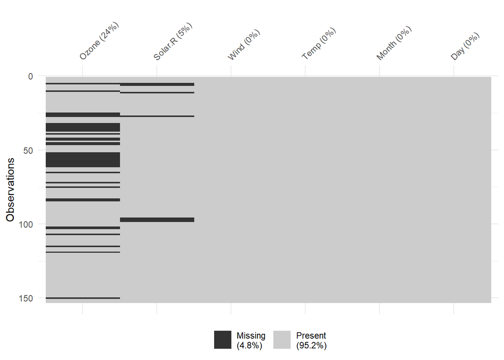

```r
# library(dplyr)
# library(visdat)
vis_miss(airquality)
```

## Analizando los valores faltanes

```r
airquality %>%

  # Crear una columna que indica si otra columa tiene valor nulo o no
  mutate(miss_ozone = is.na(Ozone)) %>%

  # Agrupa los datos por la columna creada, entre TRUE y FALSE
  group_by(miss_ozone)  %>%

  # Por cada valor, TRUE o FALSE, halla la media de cada columna
  summarise(across(everything(), median, na.rm=TRUE))
```

```
## # A tibble: 2 × 7
##   miss_ozone Ozone Solar.R  Wind  Temp Month   Day
##   <lgl>      <dbl>   <int> <dbl> <dbl> <dbl> <dbl>
## 1 FALSE       31.5     207   9.7    79     7    16
## 2 TRUE        NA       194   9.7    79     6    15
```

Para interpretar mejor los valores faltantes, los podemos organizar por una variable

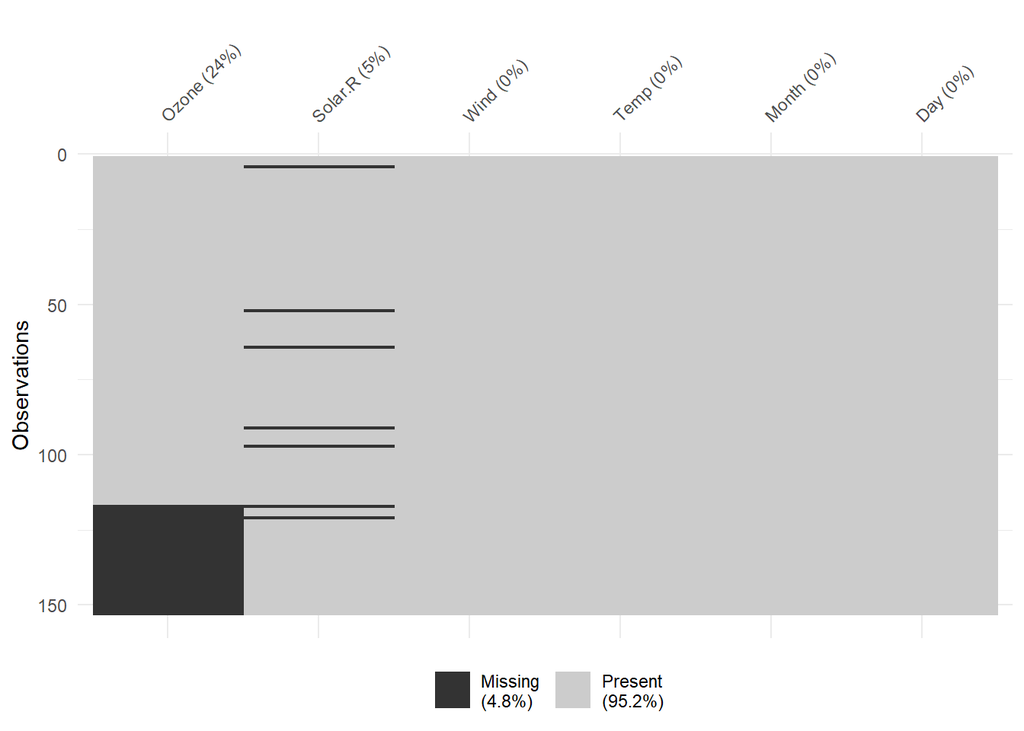

```r
airquality %>%
  arrange(Ozone) %>%
  vis_miss()
```

## Tipos de datos faltantes

### Missing Completely at Random (MCAR)

No hay una relacion entre los datos perdidos y los otros valores.

- Errores en la entrada de datos

### Missing at Random (MAR)

Relacion sistematica entre los valores faltantes y otros valores observados

### Missing Not at Random (MNAR)

Relacion directa entre los valores faltantes y los otros valores no observados

- Datos perdidos para temperaturas muy altas

## Tratando con valores faltantes

- Eliminar
- Imputar valores estadisticos

## Eliminando valores faltantes

```r
airquality %>%
  filter(!is.na(Ozone), !is.na(Solar.R)) %>%
  head(5)
```

```
##   Ozone Solar.R Wind Temp Month Day
## 1    41     190  7.4   67     5   1
## 2    36     118  8.0   72     5   2
## 3    12     149 12.6   74     5   3
## 4    18     313 11.5   62     5   4
## 5    23     299  8.6   65     5   7
```

## Reemplazado valores faltantes

```r
airquality %>%
  # Crea una columna para calcular valores faltantes
  # ifelse(condition, value_if_true, value_if_false)
  mutate(ozone_filled = ifelse(is.na(Ozone), mean(Ozone, na.rm=TRUE), Ozone)) %>%

  mutate(ozone_filled = round(x=ozone_filled, digits = 2)) %>%

  head(5)
```

```
##   Ozone Solar.R Wind Temp Month Day ozone_filled
## 1    41     190  7.4   67     5   1        41.00
## 2    36     118  8.0   72     5   2        36.00
## 3    12     149 12.6   74     5   3        12.00
## 4    18     313 11.5   62     5   4        18.00
## 5    NA      NA 14.3   56     5   5        42.13
```

## Ejercicios

- Visualizar los valores faltantes de un conjunto
- Crear una columna con valores logicos para saber si una columna tiene valores falsos o no
- Agrupar por una columna para aplicar una funcion de agregacion

```r
# # Visualize the missing values by column
# vis_miss(accounts)
#
# accounts %>%
#   # missing_inv: Is inv_amount missing?
#   mutate(missing_inv = is.na(inv_amount)) %>%
#   # Group by missing_inv
#   group_by(missing_inv) %>%
#   # Calculate mean age for each missing_inv group
#   summarize(avg_age = mean(age))
#
# # Sort by age and visualize missing vals
# accounts %>%
#   arrange(age) %>%
#   vis_miss()
```

- Dejar un set de datos limpios, con valores NA reemplazados con valores estadisticos
- Verificar/Assert que los valores de una columna contienen nulos

```r
# # Create accounts_clean
# accounts_clean <- accounts %>%
#   # Filter to remove rows with missing cust_id
#   filter(!is.na(cust_id)) %>%
#   # Add new col acct_amount_filled with replaced NAs
#   mutate(acct_amount_filled = ifelse(is.na(acct_amount), inv_amount * 5, acct_amount))
#
# # Assert that cust_id has no missing vals
# assert_all_are_not_na(accounts_clean$cust_id)
#
# # Assert that acct_amount_filled has no missing vals
# assert_all_are_not_na(accounts_clean$acct_amount_filled)
```

## Comparando strings

- Cambiar los valores de una palabra. Eliminar, insertar, cambiar o intercambiar.

## Metodos para editar distancias

- Damerau-Levenshtein: insertar, eliminar, sustituir, trasponer (cambiar posicion) - ORDEN CORRECTO
- Levenshtein: solo sustituir, insertar y eliminar
- LCS(Logest common Subsequence): solo inserta y elimina . Others

```r
# library(stringdist)
# Damerau-Levenshtein
stringdist(a='baboon', b='typhoon', method='dl')
```

```
## [1] 4
```

```r
# Inserta h           (babhoon)
# Sustituye b por t   (tabhoon)
# Sustituye a por y   (tybhoon)
# Sustituye b por p   (typhoon)
```

Ejemplos con otros metodos

```r
# LCS
stringdist(a='baboon', b='typhoon', method='lcs')
```

```
## [1] 7
```

```r
# Jaccard # Escala de 0 a 1
stringdist(a='baboon', b='typhoon', method='jaccard')
```

```
## [1] 0.75
```

## Comparando valores para no hacer el map de la unidad 2

```r
# df survey
# city, move_score

# df citiies
# city
```

Usando la libreria fuzzyjoin, se podra hacer la union de los dos dataframe, por medio de la distancia de los strings

```r
# # library(fuzzyjoin)
# stringdist_left_join(survey, cities, by='city', method='dl')
#
# # Se puede pasar el argumento max_dist para ser mas precisos con el match
# stringdist_left_join(survey, cities, by='city', method='dl', max_dist=1)
```

## Ejercicios

```r
# f1 <- 'CleaningData/zagat.rds'
# zagat <- readRDS(file = f1)
```

- Contar los valores de cada ciudad. Variaciones de los nombres
- Hacer un join con string distance

```r
# # Count the number of each city variation
# zagat %>%
#   count(city)
#
# # Join zagat and cities and look at results
# zagat %>%
#   # Left join based on stringdist using city and city_actual cols
#   stringdist_left_join(cities, by = c('city' = 'city_actual')) %>%
#   # Select the name, city, and city_actual cols
#   select(name, city, city_actual)
```

## Generando y comparando pares

Record linkage: Se trata de limpiar los dos datasets, generar pares, comparar los pares y unir los pares que tengan mayor coincidencia.

```r
# Para analizar los pares:
# library(reclin)
# pair_blocking (df_a, df_b)

# Usando blocking, se reduce el tamaño de comparacion de los datos. Es decir, se deja una variable 'fija'.
# pair_blocking (df_a, df_b, blocking_var = 'state')
```

Ahora que los valores estan comparados, se seleccionan los de mayor coincidencia.

```r
# By, la columna que queremos comparar
# default, el metodo para comparar

# pair_blocking (df_a, df_b, blocking_var = 'state') %>%
#   compare_pairs(by='name', default_comparator=lcs())

# Los comparadores pueden ser lcs(), jaccard(), jaro_winkler()
```

## Ejercicios

```r
# f1 <- 'CleaningData/zagat.rds'
# zagat <- readRDS(file = f1)
#
# f2 <- 'CleaningData/fodors.rds'
# fodors <- readRDS(file = f2)
```

### Hacer todas las comparaciones posibles entre los datos

```r
# # Load reclin
# library(reclin)
#
# # Generate pairs with same city
# pair_blocking(zagat, fodors, blocking_var='city')
```

### Comparar pares usando un metodo de comparacion

Comparar pares por ‘name’ usando lcs.

```r
# # Generate pairs
# pair_blocking(zagat, fodors, blocking_var = "city") %>%
#   # Compare pairs by name using lcs()
#   compare_pairs(by = 'name',
#       default_comparator = lcs())
```

Comparar por ‘name’, ‘phone’, and ‘addr’ usango jaro_winkler.

```r
# # Generate pairs
# pair_blocking(zagat, fodors, blocking_var = "city") %>%
#   # Compare pairs by name, phone, addr
#   compare_pairs(by=c('name', 'phone', 'addr'),
#       default_comparator=jaro_winkler())
```

## Puntuando y uniendo

Calcular el score por cada fila

- Limpiar los datasets
- Generar los pares. Compara df_a y df_b
- Comparar columnas por cada par
- Da valor usando summing o la probabilidad
- Selecciona los pares que mejor hacen match
- Link los datasets unidos

```r
# # Create pairs
# pair_blocking(zagat, fodors, blocking_var = "city") %>%
#   # Compare pairs
#   compare_pairs(by = c("name", "addr"), default_comparator = jaro_winkler()) %>%
#   # Score pairs
#   score_problink() %>%
#   # Select pairs
#   select_n_to_m() %>%
#   # Link data
#   link()
```